# Analysis

Shivam_Rajoriya

7/22/2020

loading packages

```r
library(caret)
```

```r
library(rpart)
library(rpart.plot)
library(knitr)
library(corrplot)
library(randomForest)
library(rattle)
library(RColorBrewer)
```

data loading and cleaning

```r
training <- read.csv("pml-training.csv")
testing <- read.csv("pml-testing.csv")

inTrain  <- createDataPartition(training$classe, p=0.7, list=FALSE)
TrainSet <- training[inTrain, ]
TestSet  <- training[-inTrain, ]

dim(TrainSet)
```

```
## [1] 13737   160
```

```r
dim(TestSet)
```

```
## [1] 5885  160
```

so above we could see there are 160 variables and in the cleaning process we would remove near zero variance variables ,id variables and NA variables.

```r
NZV <- nearZeroVar(TrainSet)
TrainSet <- TrainSet[, -NZV]
TestSet  <- TestSet[, -NZV]
dim(TrainSet)
```

```
## [1] 13737   106
```

```r
dim(TestSet)
```

```
## [1] 5885  106
```

```r
AllNA    <- sapply(TrainSet, function(x) mean(is.na(x))) > 0.95
TrainSet <- TrainSet[, AllNA==FALSE]
TestSet  <- TestSet[, AllNA==FALSE]
dim(TrainSet)
```

```
## [1] 13737    59
```

```r
dim(TestSet)
```

```
## [1] 5885   59
```

```r
TrainSet <- TrainSet[, -(1:5)]
TestSet  <- TestSet[, -(1:5)]
dim(TrainSet)
```

```
## [1] 13737    54
```

```r
dim(TestSet)
```

```
## [1] 5885   54
```

now after the cleaning process we are left only with 54 variables. ANALYSIS:- first lets see the correlation between different variables

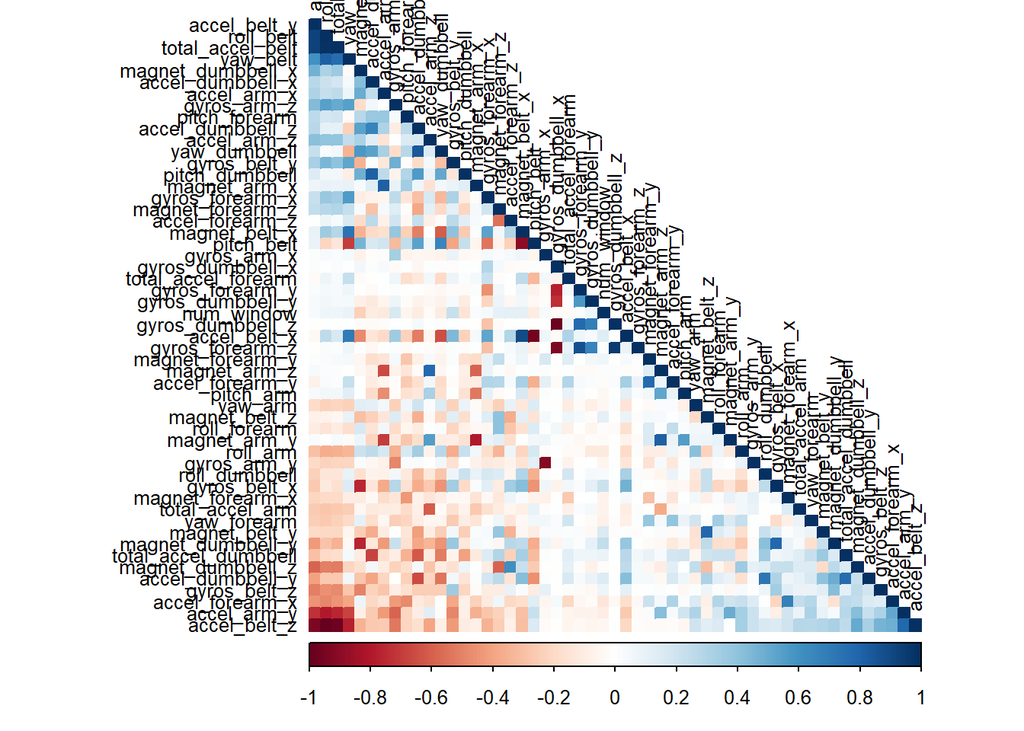

```r
corMatrix <- cor(TrainSet[, -54])
corrplot(corMatrix, order = "FPC", method = "color", type = "lower",
         tl.cex = 0.8, tl.col = rgb(0, 0, 0))
```

The highly correlated variables are shown in dark colors in the graph above. To make an evem more compact analysis, a PCA (Principal Components Analysis) could be performed as pre-processing step to the datasets. Nevertheless, as the correlations are quite few, this step will not be applied for this assignment.

predictive modelling:- method1:- Decision trees

[figure not shown]

```r
set.seed(12345)
modFitDecTree <- rpart(classe ~ ., data=TrainSet, method="class")
fancyRpartPlot(modFitDecTree)
```

predictions

```r
predictDecTree <- predict(modFitDecTree, newdata=TestSet, type="class")
confMatDecTree <- confusionMatrix(predictDecTree, TestSet$classe)
confMatDecTree
```

```
## Confusion Matrix and Statistics
##
##           Reference
## Prediction    A    B    C    D    E
##          A 1512  281   57  117  112
##          B   33  586   37   20   76
##          C   12   59  811  140   67
##          D   87  131   58  622  137
##          E   30   82   63   65  690
##
## Overall Statistics
##
##                Accuracy : 0.7172
##                  95% CI : (0.7056, 0.7287)
##     No Information Rate : 0.2845
##     P-Value [Acc > NIR] : < 2.2e-16
##
##                   Kappa : 0.6396
##
##  Mcnemar's Test P-Value : < 2.2e-16
##
## Statistics by Class:
##
##                      Class: A Class: B Class: C Class: D Class: E
## Sensitivity            0.9032  0.51449   0.7904   0.6452   0.6377
## Specificity            0.8654  0.96502   0.9428   0.9161   0.9500
## Pos Pred Value         0.7273  0.77926   0.7447   0.6010   0.7419
## Neg Pred Value         0.9574  0.89227   0.9552   0.9295   0.9209
## Prevalence             0.2845  0.19354   0.1743   0.1638   0.1839
## Detection Rate         0.2569  0.09958   0.1378   0.1057   0.1172
## Detection Prevalence   0.3533  0.12778   0.1850   0.1759   0.1580
## Balanced Accuracy      0.8843  0.73975   0.8666   0.7807   0.7939
```

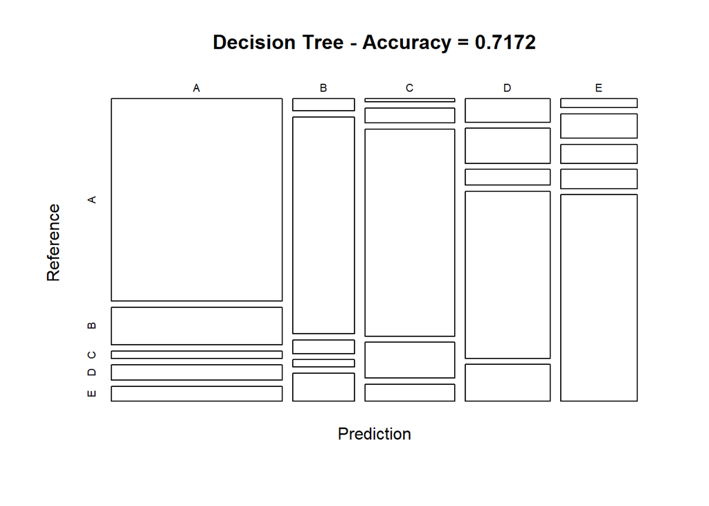

```r
plot(confMatDecTree$table, col = confMatDecTree$byClass,
     main = paste("Decision Tree - Accuracy =",
                  round(confMatDecTree$overall['Accuracy'], 4)))
```

method2:- generalised boosted method

```r
set.seed(12345)
controlGBM <- trainControl(method = "repeatedcv", number = 5, repeats = 1)
modFitGBM  <- train(classe~., data=TrainSet, method="gbm", trControl=controlGBM, verbose=FALSE)
modFitGBM$finalModel
```

```
## A gradient boosted model with multinomial loss function.
## 150 iterations were performed.
## There were 53 predictors of which 53 had non-zero influence.
```

```r
predictGBM <- predict(modFitGBM, newdata=TestSet)
confMatGBM <- confusionMatrix(predictGBM, TestSet$classe)
confMatGBM
```

```
## Confusion Matrix and Statistics
##
##           Reference
## Prediction    A    B    C    D    E
##          A 1667   13    0    2    0
##          B    6 1103   11    5    7
##          C    0   20 1010    8    5
##          D    1    3    4  946   11
##          E    0    0    1    3 1059
##
## Overall Statistics
##
##                Accuracy : 0.983
##                  95% CI : (0.9794, 0.9862)
##     No Information Rate : 0.2845
##     P-Value [Acc > NIR] : < 2.2e-16
##
##                   Kappa : 0.9785
##
##  Mcnemar's Test P-Value : NA
##
## Statistics by Class:
##
##                      Class: A Class: B Class: C Class: D Class: E
## Sensitivity            0.9958   0.9684   0.9844   0.9813   0.9787
## Specificity            0.9964   0.9939   0.9932   0.9961   0.9992
## Pos Pred Value         0.9911   0.9744   0.9684   0.9803   0.9962
## Neg Pred Value         0.9983   0.9924   0.9967   0.9963   0.9952
## Prevalence             0.2845   0.1935   0.1743   0.1638   0.1839
## Detection Rate         0.2833   0.1874   0.1716   0.1607   0.1799
## Detection Prevalence   0.2858   0.1924   0.1772   0.1640   0.1806
## Balanced Accuracy      0.9961   0.9811   0.9888   0.9887   0.9890
```

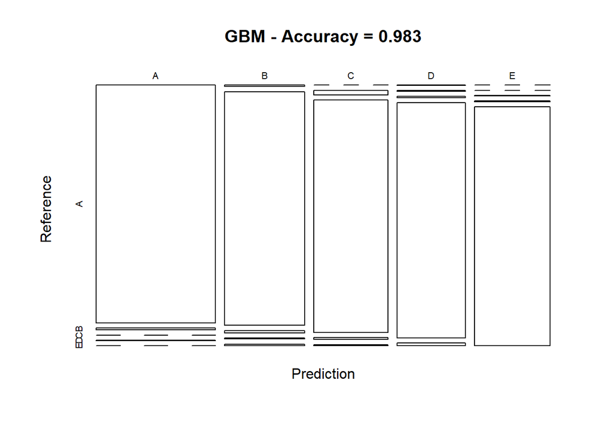

```r
plot(confMatGBM$table, col = confMatGBM$byClass,
     main = paste("GBM - Accuracy =", round(confMatGBM$overall['Accuracy'], 4)))
```

method3:- random forest

```r
set.seed(12345)
controlRF <- trainControl(method="cv", number=3, verboseIter=FALSE)
modFitRandForest <- train(classe ~ ., data=TrainSet, method="rf",
                          trControl=controlRF)
modFitRandForest$finalModel
```

```
##
## Call:
##  randomForest(x = x, y = y, mtry = param$mtry)
##                Type of random forest: classification
##                      Number of trees: 500
## No. of variables tried at each split: 27
##
##         OOB estimate of  error rate: 0.23%
## Confusion matrix:
##      A    B    C    D    E  class.error
## A 3904    1    0    0    1 0.0005120328
## B    4 2650    3    1    0 0.0030097818
## C    0    7 2389    0    0 0.0029215359
## D    0    0    9 2242    1 0.0044404973
## E    0    0    0    5 2520 0.0019801980
```

```r
predictRandForest <- predict(modFitRandForest, newdata=TestSet)
confMatRandForest <- confusionMatrix(predictRandForest, TestSet$classe)
confMatRandForest
```

```
## Confusion Matrix and Statistics
##
##           Reference
## Prediction    A    B    C    D    E
##          A 1674    2    0    0    0
##          B    0 1136    5    0    0
##          C    0    1 1018    6    0
##          D    0    0    3  958    0
##          E    0    0    0    0 1082
##
## Overall Statistics
##
##                Accuracy : 0.9971
##                  95% CI : (0.9954, 0.9983)
##     No Information Rate : 0.2845
##     P-Value [Acc > NIR] : < 2.2e-16
##
##                   Kappa : 0.9963
##
##  Mcnemar's Test P-Value : NA
##
## Statistics by Class:
##
##                      Class: A Class: B Class: C Class: D Class: E
## Sensitivity            1.0000   0.9974   0.9922   0.9938   1.0000
## Specificity            0.9995   0.9989   0.9986   0.9994   1.0000
## Pos Pred Value         0.9988   0.9956   0.9932   0.9969   1.0000
## Neg Pred Value         1.0000   0.9994   0.9984   0.9988   1.0000
## Prevalence             0.2845   0.1935   0.1743   0.1638   0.1839
## Detection Rate         0.2845   0.1930   0.1730   0.1628   0.1839
## Detection Prevalence   0.2848   0.1939   0.1742   0.1633   0.1839
## Balanced Accuracy      0.9998   0.9982   0.9954   0.9966   1.0000
```

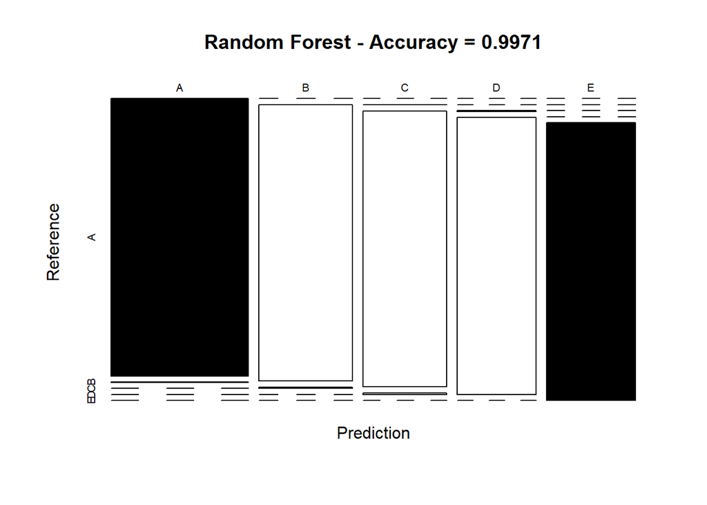

```r
plot(confMatRandForest$table, col = confMatRandForest$byClass,
     main = paste("Random Forest - Accuracy =",
                  round(confMatRandForest$overall['Accuracy'], 4)))
```

```r
predictTEST <- predict(modFitRandForest, newdata=testing)
predictTEST
```

```
##  [1] B A B A A E D B A A B C B A E E A B B B
## Levels: A B C D E
```